# Making Data Tidy

### ACE Annual Meeting

### Cincinnati, OH

#### Christopher Wolfe, MS

#### 2018-09-22

# Outline

This will be an refresher/introductory course in basic data wrangling and exploration techniques using a collection of R packages.  We will cover the following topics:

- What is 'tidy' data?
 - Tidyverse packages
 - Data visualization

[figure not shown]

# Tidy Data

What makes data 'tidy?'

- Each variable forms a column
 - Each row forms an observation
 - Each type of observational unit forms a table

**Data cleaning can take a lot of time!**

- The tidy data framework provides a standard way of data organization and facilitates data exploration and analysis.

# 'Messy' Data

| STNID | YEAR | MONTH | weather_var | 01 | 02 | 03 |
| --- | --- | --- | --- | --- | --- | --- |
| 724210-93814 | 2017 | 08 | ELEV_M | 269.1 | 269.1 | 269.1 |
| 724210-93814 | 2017 | 08 | PRCP | 0.0 | 0.0 | 1.3 |
| 724210-93814 | 2017 | 08 | RH | 70.0 | 82.1 | 85.7 |
| 724210-93814 | 2017 | 08 | TEMP | 24.3 | 22.9 | 23.0 |
| 724210-93814 | 2017 | 08 | VISIB | 16.1 | 15.3 | 14.6 |
| 724210-93814 | 2018 | 08 | ELEV_M | 269.1 | 269.1 | 269.1 |
| 724210-93814 | 2018 | 08 | PRCP | 3.0 | 0.0 | 0.0 |
| 724210-93814 | 2018 | 08 | RH | 84.6 | 85.2 | 79.3 |
| 724210-93814 | 2018 | 08 | TEMP | 21.9 | 22.4 | 23.8 |

Cincinnati weather data downloaded from R package `GSODR`.

## How to get from messy data ...

| STNID | YEAR | MONTH | weather_var | 01 | 02 | 03 |
| --- | --- | --- | --- | --- | --- | --- |
| 724210-93814 | 2017 | 08 | ELEV_M | 269.1 | 269.1 | 269.1 |
| 724210-93814 | 2017 | 08 | PRCP | 0.0 | 0.0 | 1.3 |
| 724210-93814 | 2017 | 08 | RH | 70.0 | 82.1 | 85.7 |
| 724210-93814 | 2017 | 08 | TEMP | 24.3 | 22.9 | 23.0 |
| 724210-93814 | 2017 | 08 | VISIB | 16.1 | 15.3 | 14.6 |

## to tidy data...

| STNID | YEAR | MONTH | DAY | TEMP | ELEV_M | VISIB | PRCP | RH |
| --- | --- | --- | --- | --- | --- | --- | --- | --- |
| 724210-93814 | 2017 | 08 | 01 | 24.3 | 269.1 | 16.1 | 0 | 70.0 |
| 724210-93814 | 2017 | 08 | 02 | 22.9 | 269.1 | 15.3 | 0 | 82.1 |

# Tidyverse

The `tidyverse` package is a collection of packages designed to work with each other to facilitate data cleaning and transformation (or 'wrangling').

[https://www.tidyverse.org/](https://www.tidyverse.org/)

```r
library(tidyverse)
```

- **`ggplot`**
- **`tibble`**
- **`tidyr`**
- `readr`
- **`purrr`**
- **`dplyr`**
- `stringr`
- `forcats`

# %>%

The pipe operator (`%>%`) allows you to 'pipe' multiple operations together, i.e. it takes the output of one operation and makes it the input of the next operation. So,

```r
my_other_function(my_function(X, Y), Z)
```

is equivalent to

```r
my_function(X, Y) %>%
    my_other_function(Z)
```

The pipe always assumes that the output of the function will be supplied as the *first* argument of the other function.  If this is not the case, you can specify where it should go with a `.`

```r
my_function(X, Y) %>%
    my_other_function(Z, .)
```

# %>%

*This, in turn:*

- makes your code concise and easy to read
- mitigates the need to create intermediate data sets

**The following code chunks achieve the same results:**

```r
my_df <- data.frame(x = 1:100)

* even_nums <- subset(my_df, x %% 2 == 0)
* even_nums$squared <- even_nums$x ^ 2
* plot(even_nums$x, even_nums$squared)
```

```r
* my_df %>%
*  filter(x %% 2 == 0) %>%
*  mutate(squared = x ^ 2) %>%
*  plot()
```

# `tibble`

Tibbles are a type of data frame, but with stricter requirements and better formatting.

Unlike `data.frame`, **`tibbles:`**

- never change an input variables type
- never change the names of variables, i.e. '`my variable`' will not become `my.variable`)
- subsetting (`[ ]`) a tibble will always return a tibble
- never do partial matching when extracting columns using `$`
- display a description of the column type when printed

Use `as_tibble()` or `tibble()` to coerce an object into a tibble.

```
# A tibble: 2 x 9
  STNID        YEAR  MONTH DAY    TEMP ELEV_M VISIB  PRCP    RH
  <chr>        <chr> <chr> <chr> <dbl>  <dbl> <dbl> <dbl> <dbl>
1 724210-93814 2017  08    01     24.3   269.  16.1     0  70
2 724210-93814 2017  08    02     22.9   269.  15.3     0  82.1
```

# `dplyr`

The `dplyr` package contains an array of very useful functions for data manipulation:

- **`select()`**
- **`mutate()`**
- **`rename()`**
- **`filter()`**
- **`group_by()`**
- **`summarise()`**

Other functions:

- `case_when()`
- `bind_rows()`, `bind_cols`
- `inner_join`, `full_join()`, `anti_join()`

# `dplyr::select()`

`select()` enables you to keep and drop variables that you specify

The syntax when used with `%>%` is:

```r
* select(var1, var2, var3) # THIS KEEPS COLUMNS YOU SPECIFY
* select(-var3) # ADDING A '-' PRIOR TO A VARIABLE WILL DROP IT
```

The example below creates a new variable selects the weather station ID, date information, and temperature.

```r
temp_info <- cincy_clean %>%
  select(STNID, YEAR, MONTH, DAY, TEMP) #'select(STNID:TEMP) ALSO WORKS'
```

| STNID | YEAR | MONTH | DAY | TEMP |
| --- | --- | --- | --- | --- |
| 724210-93814 | 2017 | 08 | 01 | 24.3 |
| 724210-93814 | 2017 | 08 | 02 | 22.9 |
| 724210-93814 | 2017 | 08 | 03 | 23.0 |
| 724210-93814 | 2017 | 08 | 04 | 22.7 |

# `dplyr::mutate()`

`mutate()` adds new variables to a data frame, while preserving the existing columns of data.

The syntax when used with `%>%` is:

```r
* mutate(new_variable = definition, ...)
```

The example below creates a new variable`temp_measured_in_farenheit`.

```r
farenheit <- temp_info %>%
  mutate(temp_measured_in_farenheit = TEMP * 1.8 + 32)
```

| STNID | YEAR | MONTH | DAY | TEMP | temp_measured_in_farenheit |
| --- | --- | --- | --- | --- | --- |
| 724210-93814 | 2017 | 08 | 01 | 24.3 | 75.74 |
| 724210-93814 | 2017 | 08 | 02 | 22.9 | 73.22 |
| 724210-93814 | 2017 | 08 | 03 | 23.0 | 73.40 |
| 724210-93814 | 2017 | 08 | 04 | 22.7 | 72.86 |

# `dplyr::rename()`

`rename()` allows you to rename a variable within a data frame.

The syntax when used with `%>%` is:

```r
* rename(new_variable_name = old_variable_name, ...)
```

The example below renames `temp_measured_in_farenheit` to `TEMP_F`.

```r
farenheit2 <- farenheit %>%
  rename(TEMP_F = temp_measured_in_farenheit)
```

| STNID | YEAR | MONTH | DAY | TEMP | TEMP_F |
| --- | --- | --- | --- | --- | --- |
| 724210-93814 | 2017 | 08 | 01 | 24.3 | 75.74 |
| 724210-93814 | 2017 | 08 | 02 | 22.9 | 73.22 |

# `dplyr::filter()`

`filter()` allows you to filter a data frame based on specified conditions.

The syntax when used with `%>%` is:

```r
* filter(my_variable, condition)
```

The example below filters our data frame based on values of `TEMP_F`.

```r
farenheit_filter <- farenheit2 %>%
  filter(TEMP_F > 79)
```

| STNID | YEAR | MONTH | DAY | TEMP | TEMP_F |
| --- | --- | --- | --- | --- | --- |
| 724210-93814 | 2017 | 08 | 21 | 26.4 | 79.52 |
| 724210-93814 | 2018 | 08 | 04 | 26.2 | 79.16 |
| 724210-93814 | 2018 | 08 | 05 | 26.7 | 80.06 |
| 724210-93814 | 2018 | 08 | 06 | 26.4 | 79.52 |
| 724210-93814 | 2018 | 08 | 27 | 27.1 | 80.78 |

## `dplyr::group_by()` & `summarise()`

`group_by()` takes an existing data frame and creates a 'grouped' table based on specified conditions--any functions or operations applied to the table are performed on each group

`summarise()` collapses observations in a data frame to a single summary statistic.

`group_by()` and `summarise()` make work well together.  The syntax when used with `%>%` is:

```r
* group_by(my_group_variable) %>%
* summarise(new_variable = a_function(another_variable))

# SUMMARISE TAKES COMMON SUMMARY FUNCTIONS LIKE:
# MEAN(), MEDIAN(), ETC.
```

## `dplyr::group_by()` & `summarise()`

The code below:
 1. groups the weather data by year
 2. computes the number of observations for each year and the mean and standard deviation of the temperatures:

```r
temp_summary <- farenheit2 %>%
  group_by(YEAR) %>%
  summarise(n = n(),
            mean_tempF = mean(TEMP_F, na.rm = TRUE),
            sd_tempF = sd(TEMP_F))
```

| YEAR | n | mean_tempF | sd_tempF |
| --- | --- | --- | --- |
| 2017 | 31 | 72.52323 | 3.926515 |
| 2018 | 31 | 75.37419 | 3.354150 |

# `tidyr`

The `tidyr` was designed specifically for data tidying and has many functions that interplay with `dplyr` functions:

- **`spread()`**
- **`gather()`**
- **`unite()`**

Other functions:

- `separate()`
- `nest()`
- `drop_na()`

# `tidyr::gather()`

`gather()` takes multiple columns and collapses them into 'key-value' pairs.
The `gather()` funtion is especially useful when you have columns that are not variables.
The syntax when used with `%>%` is:

```r
* gather(key, value, columns_to_gather)

# THE 'KEY' DESCRIBES THE COLUMN NAMES COLLECTED
# THE 'VALUE' DESCRIBES THE DATA WITHIN EACH COLUMN COLLECTED
```

| STNID | YEAR | MONTH | weather_var | 01 | 02 | 03 |
| --- | --- | --- | --- | --- | --- | --- |
| 724210-93814 | 2017 | 08 | RH | 70.0 | 82.1 | 85.7 |
| 724210-93814 | 2017 | 08 | TEMP | 24.3 | 22.9 | 23.0 |
| 724210-93814 | 2018 | 08 | RH | 84.6 | 85.2 | 79.3 |
| 724210-93814 | 2018 | 08 | TEMP | 21.9 | 22.4 | 23.8 |

# `tidyr::gather()`

| STNID | YEAR | MONTH | weather_var | 01 | 02 | 03 |
| --- | --- | --- | --- | --- | --- | --- |
| 724210-93814 | 2017 | 08 | RH | 70.0 | 82.1 | 85.7 |
| 724210-93814 | 2017 | 08 | TEMP | 24.3 | 22.9 | 23.0 |
| 724210-93814 | 2018 | 08 | RH | 84.6 | 85.2 | 79.3 |
| 724210-93814 | 2018 | 08 | TEMP | 21.9 | 22.4 | 23.8 |

```r
day_gather <- messy_temp %>%
  gather(key = DAY, weather_value, 5:7)
```

| STNID | YEAR | MONTH | weather_var | DAY | weather_value |
| --- | --- | --- | --- | --- | --- |
| 724210-93814 | 2017 | 08 | RH | 01 | 70.0 |
| 724210-93814 | 2017 | 08 | TEMP | 01 | 24.3 |
| 724210-93814 | 2018 | 08 | RH | 01 | 84.6 |
| 724210-93814 | 2018 | 08 | TEMP | 01 | 21.9 |

# `tidyr::spread()`

`spread()` will extend a 'key-value' pair across multiple columns.
Use `spread()` to put your data in 'wide' format.

The syntax when used with `%>%` is:

```r
* spread(key, value, ...)

# THE 'KEY' IS A COLUMN THAT DESCRIBES THE INFORMATION
# THE 'VALUE' IS THE DATA THAT IS TO BE SPREAD
```

| STNID | YEAR | MONTH | weather_var | DAY | weather_value |
| --- | --- | --- | --- | --- | --- |
| 724210-93814 | 2017 | 08 | RH | 01 | 70.0 |
| 724210-93814 | 2017 | 08 | TEMP | 01 | 24.3 |
| 724210-93814 | 2018 | 08 | RH | 01 | 84.6 |
| 724210-93814 | 2018 | 08 | TEMP | 01 | 21.9 |

# `tidyr::spread()`

| STNID | YEAR | MONTH | weather_var | DAY | weather_value |
| --- | --- | --- | --- | --- | --- |
| 724210-93814 | 2017 | 08 | RH | 01 | 70.0 |
| 724210-93814 | 2017 | 08 | TEMP | 01 | 24.3 |
| 724210-93814 | 2018 | 08 | RH | 01 | 84.6 |
| 724210-93814 | 2018 | 08 | TEMP | 01 | 21.9 |

```r
spread_weather <- day_gather %>%
  spread(key = weather_var, weather_value)
```

| STNID | YEAR | MONTH | DAY | RH | TEMP |
| --- | --- | --- | --- | --- | --- |
| 724210-93814 | 2017 | 08 | 01 | 70.0 | 24.3 |
| 724210-93814 | 2017 | 08 | 02 | 82.1 | 22.9 |
| 724210-93814 | 2017 | 08 | 03 | 85.7 | 23.0 |
| 724210-93814 | 2018 | 08 | 01 | 84.6 | 21.9 |

# `tidyr::unite()`

`unite()` pastes data from multiple columns into one column.

The syntax when used with `%>%` is:

```r
* unite(name_of_new_column, columns_to_unite, sep = " ", ...)
```

There separate colmuns for `YEAR`, `MONTH`, and `DAY`--`unite()` can be used to create one `DATE` variable.

```r
date_unite <- spread_weather %>%
  unite(DATE, YEAR:DAY, sep = "-")
```

| STNID | DATE | RH | TEMP |
| --- | --- | --- | --- |
| 724210-93814 | 2017-08-01 | 70.0 | 24.3 |
| 724210-93814 | 2017-08-02 | 82.1 | 22.9 |
| 724210-93814 | 2017-08-03 | 85.7 | 23.0 |
| 724210-93814 | 2018-08-01 | 84.6 | 21.9 |

# `purrr::map()`

The `purrr` packaged consists of tools for functional programming and working with vectors.

One of the most useful *(in my opinion)* is `map()`, which allows you to apply a function to each element of a vector.

`map()` is great for simplifying code for iterations.  Here is the syntax:

```r
* map(.x, .fun, ...)
```

- `.x` is the list or vector you with to map over
- `.f` is a function, formula, or vector
    - formulas are converted to functions and vectors are converted to extractor functions
- `...` contains additional arguments passed on to `.f`

See `?purrr::map` for details on functions as formulas and methods for specifying extractor functions

# `purrr::map()`

- `map()` will *always* return a list
- `map()` derivatives, e.g. `map_lgl()`, `map_dbl()`, are type strict and will always return the specified type or die trying
- others include: `map_if()`, `map_at()`, `walk()`

# `purrr::map()`

Let's say I want to know the mean of each weather value in my data frame:

```r
date_unite  %>%
  select(TEMP, RH) %>%
  map_dbl(mean)
```

```
 TEMP    RH
23.05 81.15
```

# `purrr::map()`

`map()` can also be used to apply a linear model or other function such as a correlation.

The following code divides our weather data frame by 'YEAR' and then calculates the correlation between temperature and relative humidity for each year

```r
cincy_clean %>%
  split(.$YEAR) %>% # SPLIT() DIVIDES THE DATA BASED ON A CONDITION
  map(~cor(.$TEMP, .$RH))
```

```
$`2017`
[1] 0.2638113

$`2018`
[1] 0.01738311
```

# `stringr`, `readr` & `forcats`

The `stringr` packaged enables you to manipulate text and strings of text easily

- `str_detect`
- `str_replace`
- `str_remove`
- `str_trim`
- `str_squish`
- `str_sort`

- `read_csv`
- `read_tsv`
- `write_csv`

The `forcats` package for reordering and modifying factor levels

- `fct_count`
- `fct_lump`

# `ggplot2`

The `ggplot2` is a versatile data visualization and graphics package. R has base graphing funtions, but `ggplot2` is far superior (*in my opinion*).

With `ggplot2`, you begin a plot with the function `ggplot()`.

- `ggplot()` creates a coordinate system that you can add layers to.

- The first argument of `ggplot()` is the dataset to use in the graph.

```r
* ggplot2::ggplot(data = my_data) # THIS CREATES A BLANK TEMPLATE
```

From there, you can add one or more layers to the template. Layers are added through 'geom functions'.

Each geom function is preceded by a plus sign (+). For `ggplot` the plus sign act similarly to the `%>%` opearator.

```r
* ggplot2::ggplot(data = my_data) +
*  geom_point()  # THIS CREATES A SCATTER PLOT
```

# `ggplot2`

- each geom function takes a `asthetic` argument, which defines how variables in your data are mapped to visual properties
- when specified within `ggplot()`, all other layers in the plot will inherit it.
- `x` and `y` arguments of `aes()` specify which variables to map to the X and Y axes.
- you can also map a third variable to your asthetic, to distinguish specific points or visually evaluate a hypothesis.
- you can specify this third variable to be a specific color, shape, size, etc.

##### The following code creates a scatter plot of temperature and humidity:

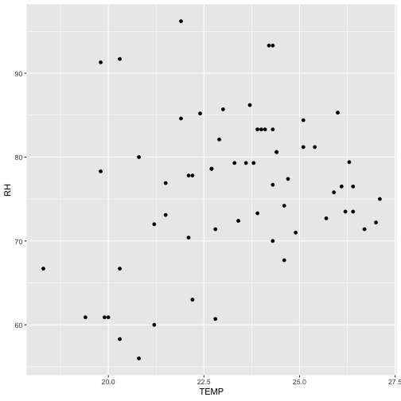

```r
ggplot2::ggplot(data = cincy_clean, aes(x = TEMP, y = RH)) +
  geom_point()
```

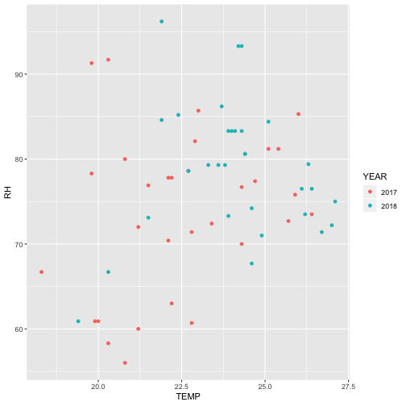

```r
ggplot2::ggplot(data = cincy_clean) +
* geom_point(mapping = aes(x = TEMP, y = RH, color = YEAR))
```

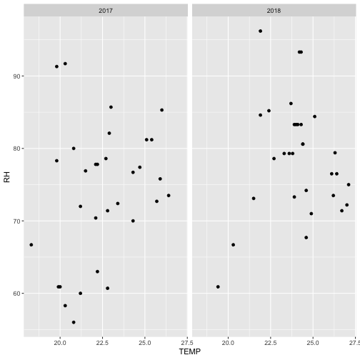

```r
ggplot2::ggplot(data = cincy_clean, aes(x = TEMP, y = RH)) +
  geom_point() +
* facet_wrap(~YEAR)
```

# `ggplot2`

`ggplot2` can be a lot more exciting!

Other common geoms include:

- `geom_boxplot()`
- `geom_line()`
- `geom_boxplot()`
- `geom_bar()`
- `geom_histogram()`
- `geom_density()`
- **`geom_sf()`**

If you are looking to visually display your data, it is likely that `ggplot2` can do it.

# Other Packages

```r
library(ggrepel)
library(viridis)
library(readxl)
library(lubridate)
```

- `lubridate`: collection of functions that makes working with dates and time easy

- `ggrepel`: annotate plots--great for timeseries data

- `viridis`: color palette--sharp, virbrant colors that print well in grey scale

- `readxl`: import *.xlsx* in tidy format

# `tidycensus`

`tidycensus` is an R packaged designed to easily retrieve US Census data from the Census API in a tidy format.

- Data from the 5-year American Community Survey is can also be downloaded

`tidycensus` also can be used to download corresponding spatial data such as census tract and county polygons using the `tigris` package.

- Spatial data is returned with simple feature (`sf`) geometry.

**`tidycensus` was designed to be used with `tidyverse` packages so that data can be manipulated, analyzed, and displayed clearly and easily.**

# `tidycensus`

To start, you must obtain a Census API key from:

http://api.census.gov/data/key_signup.html

The two basic functions for retrieving data are:

1. `get_decennial()`
2. `get_acs()`

`get_decennial()` and `get_acs()` take similar options.  Here is the syntax:

```r
get_acs(
*   geography = , # "STATE", "COUNTY", "TRACT"
*   variables = , # NAME OF GEOGRAPHIC OR DEMOGRAPHIC VARIABLE(S) TO RETRIEVE
*   year = , # YEAR OF CENSUS
*   geometry = ) # LOGICAL - IF TRUE, RETURNS SIMPLE FEATURE GEOMETRY
```

https://walkerke.github.io/tidycensus/articles/basic-usage.html

# `tidycensus`

`tidycensus` provides includes a command to search census tract and ACS variables: `tidycensus::load_variables()`

The following code pulls down a table of ACS variables from 2010:

```r
acs_vars <- tidycensus::load_variables("2010", "acs5")
```

*There are over 20K variables that get returned!*

To search for ACS variables, open the `acs_vars` data frame in the RStudio viewr and use the filter function or search box.

| name | label |
| --- | --- |
| B06011_001 | Estimate!!Median income in the past 12 months!!Total |
| B06011_002 | Estimate!!Median income in the past 12 months!!Total!!Born in state of residence |
| B06011_003 | Estimate!!Median income in the past 12 months!!Total!!Born in other state of the United States |

# `tidycensus`

```r
county_income <- get_acs(
  geography = "county",
  state = "ohio",
  year = 2010,
* variables = "B06011_001")
```

| GEOID | NAME | variable | estimate | moe |
| --- | --- | --- | --- | --- |
| 39001 | Adams County, Ohio | B06011_001 | 17265 | 846 |
| 39003 | Allen County, Ohio | B06011_001 | 22109 | 565 |
| 39005 | Ashland County, Ohio | B06011_001 | 22638 | 898 |
| 39007 | Ashtabula County, Ohio | B06011_001 | 20546 | 438 |
| 39009 | Athens County, Ohio | B06011_001 | 11886 | 533 |

# References

R for Data Science

- http://r4ds.had.co.nz/

`tidycensus`

- https://walkerke.github.io/tidycensus/

GSODR

- https://github.com/ropensci/GSODR